# Clustering of H3K27ac peaks III

last changed: 2023-08-29

# Hierarchical Clustering

Load the `rlog` transformed DESeq data set and construct the required data frames. The function `assay` returns the values and `colData` returns the information about the experimental design.

```r
> rlog.heat <- readRDS(file = "./../Significance_testing/Data/rlog_H3K27ac_sig.rds")
> head(rlog.heat)
```

```
## class: DESeqTransform
## dim: 6 22
## metadata(1): version
## assays(1): ''
## rownames(6): chr1:777858-779502 chr1:998679-1002226 ...
##   chr1:1202874-1203283 chr1:1204698-1205972
## rowData names(7): baseMean baseVar ... dispFit rlogIntercept
## colnames(22): U2OS31_T0h_Rep1 U2OS31_T0h_Rep2 ... U2OS33_T4h_Rep2
##   U2OS33_T4h_Rep3
## colData names(4): construct replica time sizeFactor
```

```r
> m.H3.ac <- assay(rlog.heat)
> head(m.H3.ac)
```

```
##                      U2OS31_T0h_Rep1 U2OS31_T0h_Rep2 U2OS31_T0h_Rep3
## chr1:777858-779502          6.644882        7.047764        6.843831
## chr1:998679-1002226         7.498502        8.017057        7.874621
## chr1:1062482-1064839        6.936592        7.241185        7.003333
## chr1:1200210-1201807        6.934436        7.513163        7.134582
## chr1:1202874-1203283        3.356625        3.822526        3.791844
## chr1:1204698-1205972        4.254665        4.742891        4.917207
##                      U2OS31_T1h_Rep1 U2OS31_T1h_Rep2 U2OS31_T1h_Rep3
## chr1:777858-779502          6.517474        6.703328        6.873693
## chr1:998679-1002226         7.998243        8.467343        8.302465
## chr1:1062482-1064839        7.626672        7.742398        7.666093
## chr1:1200210-1201807        7.565851        7.760794        7.677449
## chr1:1202874-1203283        3.934671        4.003246        4.427764
## chr1:1204698-1205972        5.122689        5.762440        5.675096
##                      U2OS31_T2h_Rep1 U2OS31_T2h_Rep2 U2OS31_T4h_Rep1
## chr1:777858-779502          6.640883        6.517778        7.088908
## chr1:998679-1002226         8.054719        7.931793        7.407744
## chr1:1062482-1064839        7.485299        7.034059        7.056250
## chr1:1200210-1201807        7.743524        7.840957        7.348425
## chr1:1202874-1203283        4.307967        4.287953        3.557889
## chr1:1204698-1205972        5.234419        5.331420        4.751368
##                      U2OS31_T4h_Rep2 U2OS33_T0h_Rep1 U2OS33_T0h_Rep2
## chr1:777858-779502          6.653240        7.191532        7.220966
## chr1:998679-1002226         6.942857        7.627258        8.156514
## chr1:1062482-1064839        6.902423        6.772283        6.647448
## chr1:1200210-1201807        7.378682        7.085342        7.456336
## chr1:1202874-1203283        3.467119        3.387016        3.619754
## chr1:1204698-1205972        4.530288        4.591392        5.044981
##                      U2OS33_T0h_Rep3 U2OS33_T1h_Rep1 U2OS33_T1h_Rep2
## chr1:777858-779502          6.802851        7.140648        7.189506
## chr1:998679-1002226         7.983411        8.777242        9.068580
## chr1:1062482-1064839        6.585536        7.619277        7.763149
## chr1:1200210-1201807        6.967209        7.775634        8.128662
## chr1:1202874-1203283        3.725291        4.279163        4.098830
## chr1:1204698-1205972        4.590939        5.295389        5.532942
##                      U2OS33_T1h_Rep3 U2OS33_T2h_Rep1 U2OS33_T2h_Rep2
## chr1:777858-779502          6.831799        6.866234        6.606008
## chr1:998679-1002226         8.777677        8.763022        8.849320
## chr1:1062482-1064839        7.778628        7.525321        7.322127
## chr1:1200210-1201807        7.896455        7.767084        7.746612
## chr1:1202874-1203283        4.437457        4.206605        4.138575
## chr1:1204698-1205972        5.649694        5.825150        5.600117
##                      U2OS33_T2h_Rep3 U2OS33_T4h_Rep1 U2OS33_T4h_Rep2
## chr1:777858-779502          6.513053        6.555047        7.007727
## chr1:998679-1002226         8.339706        7.537214        7.723678
## chr1:1062482-1064839        6.921511        7.219436        6.845753
## chr1:1200210-1201807        7.732785        7.415408        7.178515
## chr1:1202874-1203283        4.006166        3.591726        3.267218
## chr1:1204698-1205972        5.604686        5.088697        4.895844
##                      U2OS33_T4h_Rep3
## chr1:777858-779502          6.456581
## chr1:998679-1002226         7.689625
## chr1:1062482-1064839        6.742765
## chr1:1200210-1201807        7.139855
## chr1:1202874-1203283        3.315074
## chr1:1204698-1205972        5.347766
```

```r
> info.H3.ac <- data.frame(colData(rlog.heat))
> paged_table(info.H3.ac)
```

|  | construct | replica | time | sizeFactor |
| --- | --- | --- | --- | --- |
| U2OS31_T0h_Rep1 | U2OS31 | Rep1 | 0 | 0.9713745 |
| U2OS31_T0h_Rep2 | U2OS31 | Rep2 | 0 | 0.9677638 |
| U2OS31_T0h_Rep3 | U2OS31 | Rep3 | 0 | 1.4070125 |
| U2OS31_T1h_Rep1 | U2OS31 | Rep1 | 1 | 1.3427846 |
| U2OS31_T1h_Rep2 | U2OS31 | Rep2 | 1 | 1.3689437 |
| U2OS31_T1h_Rep3 | U2OS31 | Rep3 | 1 | 1.3748857 |
| U2OS31_T2h_Rep1 | U2OS31 | Rep1 | 2 | 0.9648885 |
| U2OS31_T2h_Rep2 | U2OS31 | Rep2 | 2 | 1.3894730 |
| U2OS31_T4h_Rep1 | U2OS31 | Rep1 | 4 | 1.0879097 |
| U2OS31_T4h_Rep2 | U2OS31 | Rep2 | 4 | 1.2114263 |

[output cut: 12 more lines]

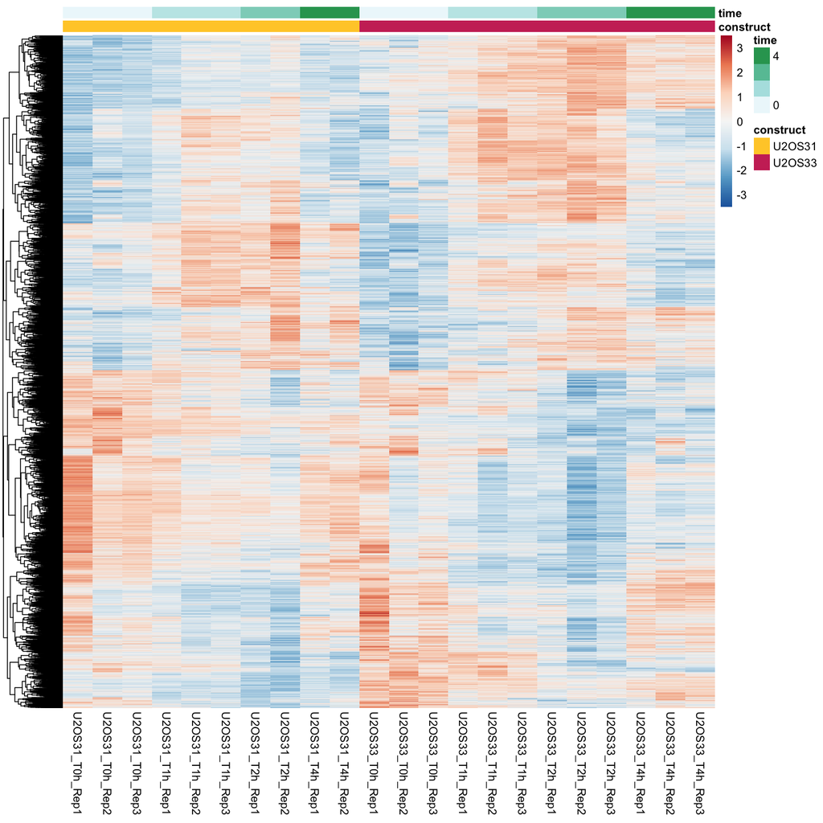

```r
> col <- colorRampPalette(rev(brewer.pal(n = 7, name = "RdBu")))(100)
> ann.col <- list(construct = c(U2OS31 = "#FFCC33", U2OS33 = "#CC3366"))
>
> heat.hieracial <- pheatmap(m.H3.ac,
+                   cluster_cols = F,
+                   show_rownames = F,
+                   scale = "row",
+                   color = col,
+                   annotation_col = info.H3.ac[, c("construct", "time")],
+                   annotation_colors = ann.col)
```

# Kmeans Clustering

To get a better separation of the data, kmeans clustering was performed. Since the H3K27ac data was yielded from two separate constructs U2OS31 (histone H3.1) and U2OS33 (histone H3.3), the data was separated by construct and scaled to Z-scores using the function `scale`.

```r
> m.H3.1 <- m.H3.ac[, info.H3.ac$construct == "U2OS31"]
> m.H3.3 <- m.H3.ac[, info.H3.ac$construct == "U2OS33"]
>
> norm.m.H3.1 <- t(scale(t(m.H3.1)))
> norm.m.H3.3 <- t(scale(t(m.H3.3)))
>
> norm.m.H3 <- cbind(norm.m.H3.1, norm.m.H3.3)
```

Next, `kmeans` was used to perform the clustering and a factor indicating the clusters was added to each of the scaled matrices. The clustering for `centers = 3` (3 cluster) yielded the best result, as more clusters divided data with a similar course.

```r
> clus.kmeans <- kmeans(norm.m.H3, 3)
>
> lapply(clus.kmeans, head)
```

```
## $cluster
##   chr1:777858-779502  chr1:998679-1002226 chr1:1062482-1064839
##                    2                    1                    1
## chr1:1200210-1201807 chr1:1202874-1203283 chr1:1204698-1205972
##                    1                    1                    1
##
## $centers
##   U2OS31_T0h_Rep1 U2OS31_T0h_Rep2 U2OS31_T0h_Rep3 U2OS31_T1h_Rep1
## 1      -0.9107094      -0.7566079      -0.7069159     -0.10780233
## 2       0.6759502       1.0260492       0.6292887      0.24464281
## 3       1.4963678       0.1281274       0.4890254     -0.02324492
##   U2OS31_T1h_Rep2 U2OS31_T1h_Rep3 U2OS31_T2h_Rep1 U2OS31_T2h_Rep2
## 1       0.6502129      0.57607047       0.5174009        1.022184
## 2       0.1274272     -0.01055102      -0.6339156       -1.159889
## 3      -0.6248805     -0.51913494      -0.6324137       -1.058342
##   U2OS31_T4h_Rep1 U2OS31_T4h_Rep2 U2OS33_T0h_Rep1 U2OS33_T0h_Rep2
## 1      -0.1571308      -0.1267021      -1.0838748      -0.9035251
## 2      -0.4080304      -0.4909725       0.8059179       1.0772501
## 3       0.3000225       0.4444727       1.4928046       0.2018640
##   U2OS33_T0h_Rep3 U2OS33_T1h_Rep1 U2OS33_T1h_Rep2 U2OS33_T1h_Rep3
## 1      -0.7184915    -0.051680842       0.3907944       0.4288748
## 2       0.6743626     0.436558924       0.5116969       0.1474220
## 3       0.6599322    -0.008400519      -0.6667306      -0.3415816
##   U2OS33_T2h_Rep1 U2OS33_T2h_Rep2 U2OS33_T2h_Rep3 U2OS33_T4h_Rep1
## 1       0.7437703       0.9385652       0.8152558     -0.08010668
## 2      -0.5926291      -0.9649092      -0.9629240     -0.49604915
## 3      -0.4862840      -1.2731167      -0.8158056      0.45385189
##   U2OS33_T4h_Rep2 U2OS33_T4h_Rep3
## 1      -0.2484016      -0.2311799
## 2      -0.2484116      -0.3882853
## 3       0.3193091       0.4641572
##
## $totss
## [1] 217605.8
##
## $withinss
## [1] 59666.03 23202.91 28801.15
##
## $tot.withinss
## [1] 111670.1
##
## $betweenss
## [1] 105935.7
##
## $size
## [1] 5468 2219 3301
##
## $iter
## [1] 2
##
## $ifault
## [1] 0
```

```r
> saveRDS(clus.kmeans, "./Data/kmeans.rds")
>
> m.kmeans <- cbind(norm.m.H3, cluster = as.factor(clus.kmeans$cluster))
> m.kmeans <- m.kmeans[order(m.kmeans[, "cluster"]), ]
>
> m.kmeans.H31 <- m.kmeans[, c(1:10, 23)]
> m.kmeans.H33 <- m.kmeans[, 11:23]
```

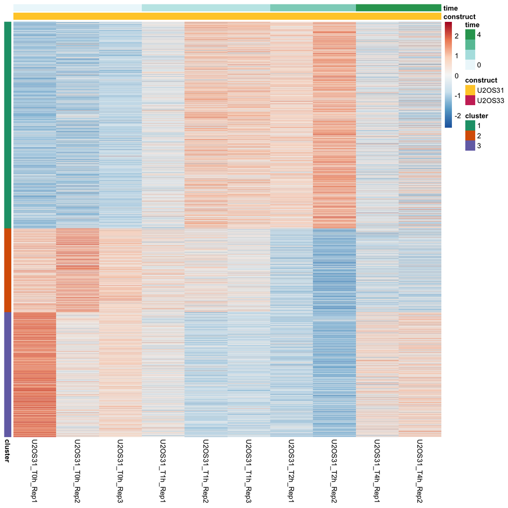

```r
> col <- colorRampPalette(rev(brewer.pal(n = 7, name = "RdBu")))(100)
> col2 <- brewer.pal(n = 8, name = "Dark2")
> clus.col <- c("1" = col2[1], "2" = col2[2], "3" = col2[3])
> ann.col2 <- list(construct = c(U2OS31 = "#FFCC33", U2OS33 = "#CC3366"), cluster = clus.col[1:3])
>
> heat.kmeans.H31 <- pheatmap(m.kmeans.H31[ ,-ncol(m.kmeans.H31)],
+                         cluster_rows = F,
+                         cluster_cols = F,
+                         show_rownames = F,
+                         color = col,
+                         annotation_col = info.H3.ac[, c("construct", "time")],
+                         annotation_row = data.frame(cluster = as.factor(m.kmeans[ ,"cluster"])),
+                         annotation_colors = ann.col2)
```

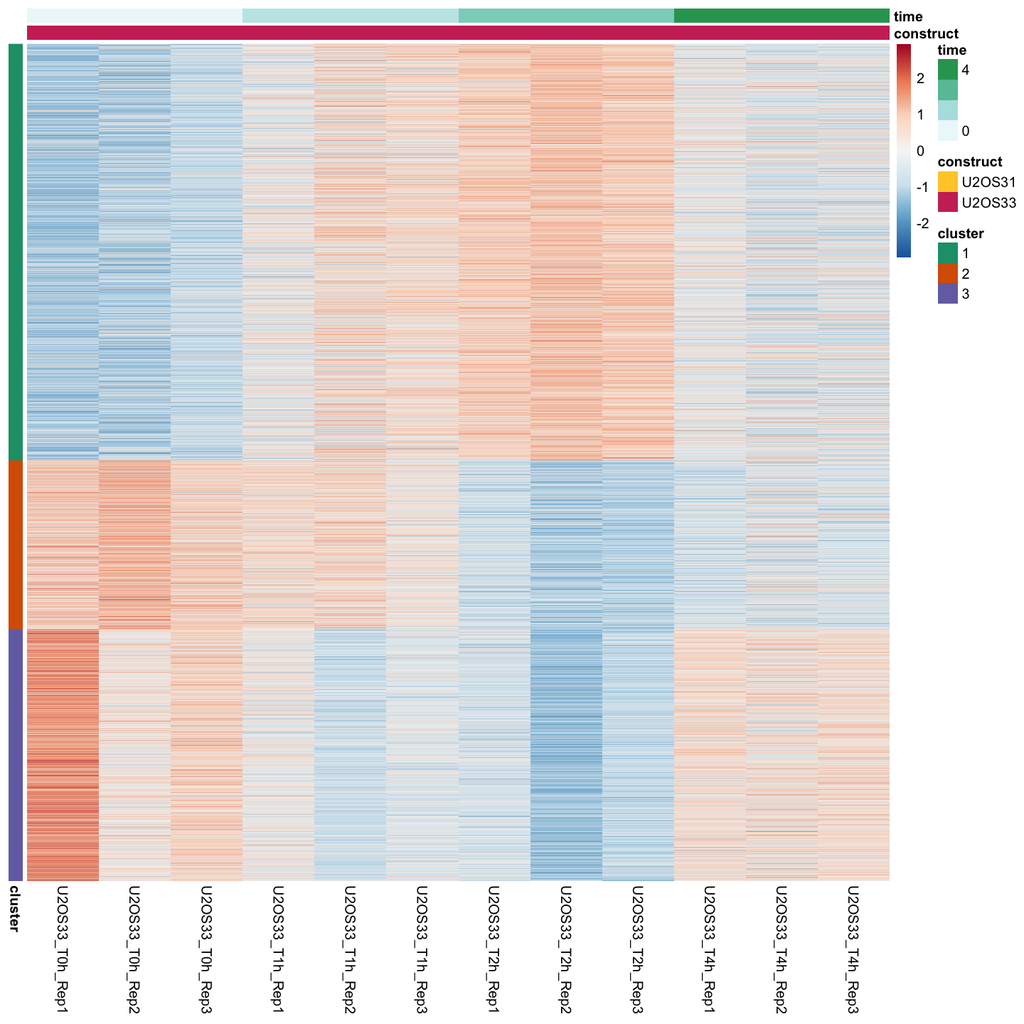

```r
> heat.kmeans.H33 <- pheatmap(m.kmeans.H33[ ,-ncol(m.kmeans.H33)],
+                         cluster_rows = F,
+                         cluster_cols = F,
+                         show_rownames = F,
+                         color = col,
+                         annotation_col = info.H3.ac[, c("construct", "time")],
+                         annotation_row = data.frame(cluster = as.factor(m.kmeans[, "cluster"])),
+                         annotation_colors = ann.col2)
```

Lastly, the cluster centroids (Z-scores) were plotted separately to visualize the change in H3K27ac over time between the two constructs.

```r
> kmeans <- melt(clus.kmeans$centers)
> ind <- match(kmeans$Var2, rownames(info.H3.ac))
> data.kmeans <- cbind(kmeans, info.H3.ac[ind, c("time", "construct")])
> colnames(data.kmeans) <- c("cluster", "name", "Z_score", "time", "construct")
>
> paged_table(data.kmeans)
```

|  | cluster | name | Z_score | time | construct |
| --- | --- | --- | --- | --- | --- |
| U2OS31_T0h_Rep1 | 1 | U2OS31_T0h_Rep1 | -0.910709449 | 0 | U2OS31 |
| U2OS31_T0h_Rep1.1 | 2 | U2OS31_T0h_Rep1 | 0.675950177 | 0 | U2OS31 |
| U2OS31_T0h_Rep1.2 | 3 | U2OS31_T0h_Rep1 | 1.496367834 | 0 | U2OS31 |
| U2OS31_T0h_Rep2 | 1 | U2OS31_T0h_Rep2 | -0.756607866 | 0 | U2OS31 |
| U2OS31_T0h_Rep2.1 | 2 | U2OS31_T0h_Rep2 | 1.026049183 | 0 | U2OS31 |
| U2OS31_T0h_Rep2.2 | 3 | U2OS31_T0h_Rep2 | 0.128127413 | 0 | U2OS31 |
| U2OS31_T0h_Rep3 | 1 | U2OS31_T0h_Rep3 | -0.706915949 | 0 | U2OS31 |
| U2OS31_T0h_Rep3.1 | 2 | U2OS31_T0h_Rep3 | 0.629288726 | 0 | U2OS31 |
| U2OS31_T0h_Rep3.2 | 3 | U2OS31_T0h_Rep3 | 0.489025384 | 0 | U2OS31 |
| U2OS31_T1h_Rep1 | 1 | U2OS31_T1h_Rep1 | -0.107802333 | 1 | U2OS31 |

[output cut: 56 more lines]

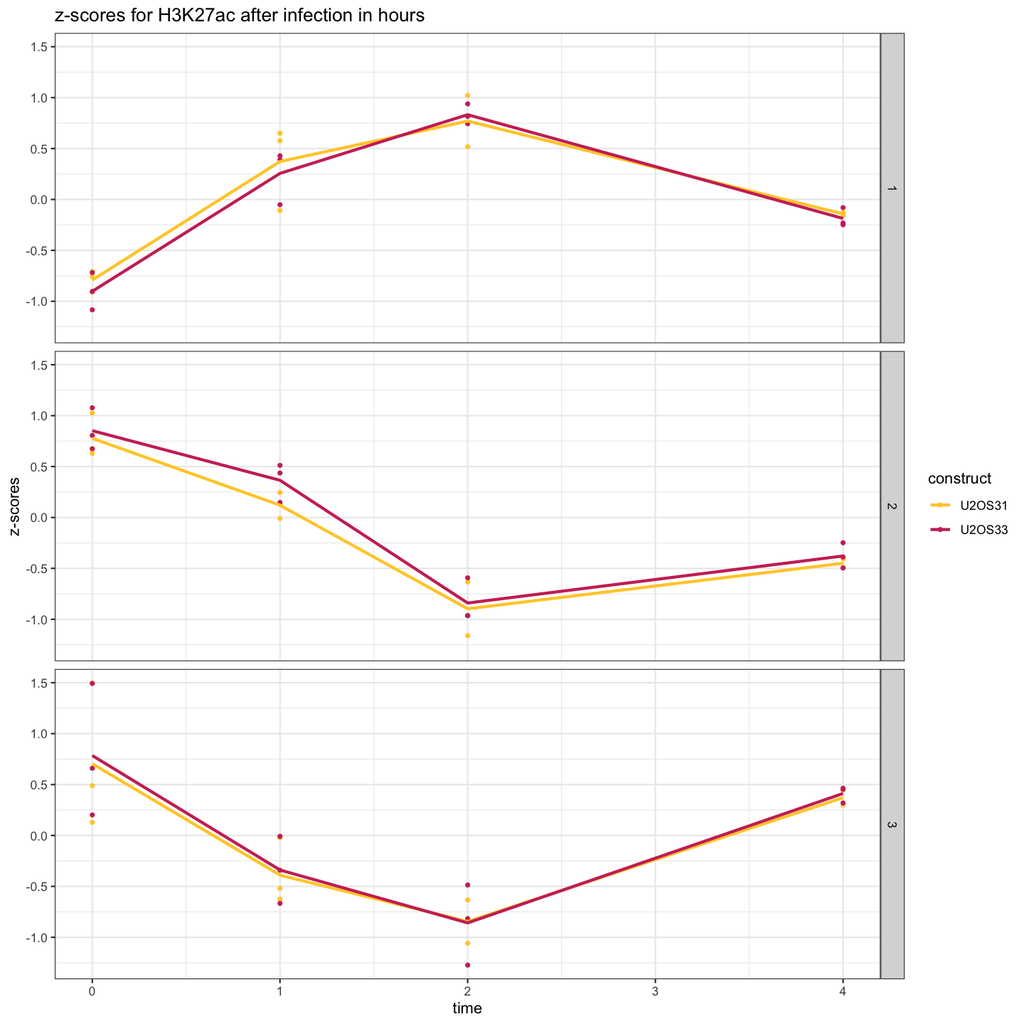

```r
> ggplot(data.kmeans) +
+   geom_point(aes(x = time, y = Z_score, color = construct), size = 1) +
+   stat_summary(aes(x = time, y = Z_score, color = construct), fun = mean, geom = "line", linewidth = 1) +
+   facet_grid(rows = data.kmeans$cluster) +
+   scale_color_manual(values = c("#FFCC33", "#CC3366")) +
+   theme_bw() +
+   labs(title = "z-scores for H3K27ac after infection in hours", y = "z-scores")
```

## References - packages

- Ahlmann-Eltze C, Hickey P, Pagès H (2023). *MatrixGenerics: S4 Generic Summary Statistic Functions that Operate on Matrix-Like Objects*. doi:10.18129/B9.bioc.MatrixGenerics https://doi.org/10.18129/B9.bioc.MatrixGenerics, R package version 1.12.2, https://bioconductor.org/packages/MatrixGenerics.
- Allaire J, Xie Y, Dervieux C, McPherson J, Luraschi J, Ushey K, Atkins A, Wickham H, Cheng J, Chang W, Iannone R (2023). *rmarkdown: Dynamic Documents for R*. R package version 2.23, https://github.com/rstudio/rmarkdown. Xie Y, Allaire J, Grolemund G (2018). *R Markdown: The Definitive Guide*. Chapman and Hall/CRC, Boca Raton, Florida. ISBN 9781138359338, https://bookdown.org/yihui/rmarkdown. Xie Y, Dervieux C, Riederer E (2020). *R Markdown Cookbook*. Chapman and Hall/CRC, Boca Raton, Florida. ISBN 9780367563837, https://bookdown.org/yihui/rmarkdown-cookbook.
- Arora S, Morgan M, Carlson M, Pagès H (2023). *GenomeInfoDb: Utilities for manipulating chromosome names, including modifying them to follow a particular naming style*. doi:10.18129/B9.bioc.GenomeInfoDb https://doi.org/10.18129/B9.bioc.GenomeInfoDb, R package version 1.36.0, https://bioconductor.org/packages/GenomeInfoDb.
- Bengtsson H (2023). *matrixStats: Functions that Apply to Rows and Columns of Matrices (and to Vectors)*. R package version 1.0.0, https://CRAN.R-project.org/package=matrixStats.
- Huber W, Carey VJ, Gentleman R, Anders S, Carlson M, Carvalho BS, Bravo HC, Davis S, Gatto L, Girke T, Gottardo R, Hahne F, Hansen KD, Irizarry RA, Lawrence M, Love MI, MacDonald J, Obenchain V, Ole’s AK, Pag`es H, Reyes A, Shannon P, Smyth GK, Tenenbaum D, Waldron L, Morgan M (2015). “Orchestrating high-throughput genomic analysis with Bioconductor.” *Nature Methods*, *12*(2), 115-121. http://www.nature.com/nmeth/journal/v12/n2/full/nmeth.3252.html.
- Huber, W., Carey, J. V, Gentleman, R., Anders, S., Carlson, M., Carvalho, S. B, Bravo, C. H, Davis, S., Gatto, L., Girke, T., Gottardo, R., Hahne, F., Hansen, D. K, Irizarry, A. R, Lawrence, M., Love, I. M, MacDonald, J., Obenchain, V., Ole’s, K. A, Pag`es, H., Reyes, A., Shannon, P., Smyth, K. G, Tenenbaum, D., Waldron, L., Morgan, M. (2015). “Orchestrating high-throughput genomic analysis with Bioconductor.” *Nature Methods*, *12*(2), 115-121. http://www.nature.com/nmeth/journal/v12/n2/full/nmeth.3252.html.
- Kolde R (2019). *pheatmap: Pretty Heatmaps*. R package version 1.0.12, https://CRAN.R-project.org/package=pheatmap.
- Lawrence M, Huber W, Pagès H, Aboyoun P, Carlson M, Gentleman R, Morgan M, Carey V (2013). “Software for Computing and Annotating Genomic Ranges.” *PLoS Computational Biology*, *9*. doi:10.1371/journal.pcbi.1003118 https://doi.org/10.1371/journal.pcbi.1003118, http://www.ploscompbiol.org/article/info%3Adoi%2F10.1371%2Fjournal.pcbi.1003118.
- Lawrence M, Huber W, Pagès H, Aboyoun P, Carlson M, Gentleman R, Morgan M, Carey V (2013). “Software for Computing and Annotating Genomic Ranges.” *PLoS Computational Biology*, *9*. doi:10.1371/journal.pcbi.1003118 https://doi.org/10.1371/journal.pcbi.1003118, http://www.ploscompbiol.org/article/info%3Adoi%2F10.1371%2Fjournal.pcbi.1003118.
- Love MI, Huber W, Anders S (2014). “Moderated estimation of fold change and dispersion for RNA-seq data with DESeq2.” *Genome Biology*, *15*, 550. doi:10.1186/s13059-014-0550-8 https://doi.org/10.1186/s13059-014-0550-8.
- Makowski D, Lüdecke D, Patil I, Thériault R, Ben-Shachar M, Wiernik B (2023). “Automated Results Reporting as a Practical Tool to Improve Reproducibility and Methodological Best Practices Adoption.” *CRAN*. https://easystats.github.io/report/.
- Morgan M, Obenchain V, Hester J, Pagès H (2023). *SummarizedExperiment: SummarizedExperiment container*. doi:10.18129/B9.bioc.SummarizedExperiment https://doi.org/10.18129/B9.bioc.SummarizedExperiment, R package version 1.30.2, https://bioconductor.org/packages/SummarizedExperiment.
- Neuwirth E (2022). *RColorBrewer: ColorBrewer Palettes*. R package version 1.1-3, https://CRAN.R-project.org/package=RColorBrewer.
- Pagès H, Lawrence M, Aboyoun P (2023). *S4Vectors: Foundation of vector-like and list-like containers in Bioconductor*. doi:10.18129/B9.bioc.S4Vectors https://doi.org/10.18129/B9.bioc.S4Vectors, R package version 0.38.1, https://bioconductor.org/packages/S4Vectors.
- R Core Team (2023). *R: A Language and Environment for Statistical Computing*. R Foundation for Statistical Computing, Vienna, Austria. https://www.R-project.org/.
- Wickham H (2007). “Reshaping Data with the reshape Package.” *Journal of Statistical Software*, *21*(12), 1-20. http://www.jstatsoft.org/v21/i12/.
- Wickham H (2016). *ggplot2: Elegant Graphics for Data Analysis*. Springer-Verlag New York. ISBN 978-3-319-24277-4, https://ggplot2.tidyverse.org.
- Xie Y (2023). *knitr: A General-Purpose Package for Dynamic Report Generation in R*. R package version 1.43, https://yihui.org/knitr/. Xie Y (2015). *Dynamic Documents with R and knitr*, 2nd edition. Chapman and Hall/CRC, Boca Raton, Florida. ISBN 978-1498716963, https://yihui.org/knitr/. Xie Y (2014). “knitr: A Comprehensive Tool for Reproducible Research in R.” In Stodden V, Leisch F, Peng RD (eds.), *Implementing Reproducible Computational Research*. Chapman and Hall/CRC. ISBN 978-1466561595.